# Washington D.C Metropolitan Crime Data

## Introduction

In the past decade the field of computer science has drastically become more involved in society. With this in mind, data has also become essential and vital to solving problems in this world. As a result, of this importance of data, Data Science has come to the forefront in order to help make changes and improvements of these everlasting problems that we all see the media and through our experiences. And its because of these individuals, collecting data, analyzing trends and patterns through the use of programming tools has brought us great discoveries and accomplishments.

In that respect, we will go over the basic processes of what Data Scientist go through to understand and test data.. Specifically, we will adventure through a number of steps like data collection, how to proccess the data in regards to cleaning up, curating, tidying data, and etc. Next, exploring through all the different graphical techniques to visualize ones data in order to see patterns and trends. In addition, to better understand all the different features of the data set. Fourth, we will go through machine learning algorithmn to help tests hypothesis and make predictions. Finally, come up with a decision based on the prior steps mentioned previously.

All in all, before exploring through these steps, we will look at a data set that involves information about the crime activity in the city of Washington D.C. Moreover, wheather you are an individual living in Maryland, someone living on the East Coast or a computer science major, you might possibly find yourself a job here in Washington D.C, which is one of the top cities with a highest growth rate in computer science jobs in the country. For more information, [The 10 best cities for getting a job in tech beyond Silicon Valley](https://www.cnbc.com/2017/07/27/tech-jobs-silicon-valley.html). Consequently, one might be very curious about the crime acitvity in DC. We should be aware of the crime activity especially if your planning on someday living here. With all that being said, lets get started!

## Getting Started

If you don't have Python on your device, you can use the [Anaconda Python](https://www.anaconda.com/download/#macos) to install most of the necessary packages you. In addition, this notebook tutorial will use be using several libraries listed below (Click for more details):

- [Pandas](https://www.tutorialspoint.com/python_pandas/)
- [Numpy](https://www.tutorialspoint.com/numpy/)
- [Matplotlib](https://matplotlib.org/)
- [Scikit-learn](http://scikit-learn.org/stable/documentation.html)
- [Folium](https://github.com/python-visualization/folium)

```python
import numpy as np
import pandas as pd
import sklearn
import matplotlib.pyplot as plt
import folium
from folium.plugins import MarkerCluster
from sklearn.ensemble import RandomForestClassifier
from sklearn.metrics import accuracy_score
import warnings
warnings.filterwarnings('ignore')
```

## 1. Data Collection

In today's generation, obtaining datasets can be very easily done. There are ton of sources out there on the web, which include some of the popular sites that supply datasets like Kaggle, CrowdAI, and DrivenData, or from other web pages such as IMDB, NASA, CDC sites, and much more. But for this tutorial in particular,we will need to download the DC crime dataset from Kaggle: [DC Metro Crime Data](https://www.kaggle.com/vinchinzu/dc-metro-crime-data/data)

```python
# Loading the data frame
dc_crime_df = pd.read_csv("dc_crime_add_vars.csv")
# Show the data frame
dc_crime_df.head()
```

|  | Unnamed: 0 | X | REPORT_DAT | SHIFT | OFFENSE | METHOD | BLOCK | DISTRICT | PSA | WARD | ... | year | month | day | hour | minute | second | EW | NS | quad | crimetype |
| --- | --- | --- | --- | --- | --- | --- | --- | --- | --- | --- | --- | --- | --- | --- | --- | --- | --- | --- | --- | --- | --- |
| 0 | 1 | 1 | 8/31/2008 8:47:00 PM | EVENING | THEFT/OTHER | OTHERS | 3500 - 3599 BLOCK OF R STREET NW | 2.0 | 206.0 | 2 | ... | 2008 | 8 | 31 | 20 | 47 | 0 | West | North | Northwest | Non-Violent |
| 1 | 2 | 2 | 9/1/2008 12:45:00 AM | MIDNIGHT | MOTOR VEHICLE THEFT | OTHERS | 2000 - 2015 BLOCK OF O STREET NW | 2.0 | 208.0 | 2 | ... | 2008 | 9 | 1 | 0 | 45 | 0 | West | North | Northwest | Non-Violent |
| 2 | 3 | 3 | 9/1/2008 3:00:00 AM | MIDNIGHT | THEFT/OTHER | OTHERS | 700 - 799 BLOCK OF 11TH STREET NW | 1.0 | 101.0 | 2 | ... | 2008 | 9 | 1 | 3 | 0 | 0 | East | North | Northeast | Non-Violent |
| 3 | 4 | 4 | 9/9/2008 7:46:00 AM | DAY | THEFT/OTHER | OTHERS | 1700 - 1799 BLOCK OF P STREET NW | 2.0 | 208.0 | 2 | ... | 2008 | 9 | 9 | 7 | 46 | 0 | West | North | Northwest | Non-Violent |
| 4 | 5 | 5 | 8/24/2008 8:00:00 PM | EVENING | MOTOR VEHICLE THEFT | OTHERS | 500 - 599 BLOCK OF INDIANA AVENUE NW | 1.0 | 102.0 | 2 | ... | 2008 | 8 | 24 | 20 | 0 | 0 | East | North | Northeast | Non-Violent |

5 rows × 32 columns

As on can see from above, this here is dataframe that represents the DC crime data which has information on reported date crime dates, time of day of crimes committed, type of criminal acts, street addresses, quadrant, and etc for all the crimes committed from the year 2008 to 2017.

## 2. Data Processing

In order to prepare the data for the next step, we will have to clean up the data frame first. Some of the things that should come to mind while executing this step are: is there anything wrong with the data? Do I need to remove any missing data values?Do how I rearrange or change columns or rows to make it more accessible for data analysis?

With that in mind, looking at the dataframe above there are a lot of unecessary columns that wont be utilized for analysis and testing later. So in doing so, we will drop all the columns that wont be needed by using the drop description. For more information, [here.](https://pandas.pydata.org/pandas-docs/version/0.21/generated/pandas.DataFrame.drop.html)

### 2.1 Tidy Data

```python
# Using drop function to drop specified columns.
columns = ['Unnamed: 0', 'METHOD','BLOCK','DISTRICT','PSA','WARD','ANC','NEIGHBORHOOD_CLUSTER'\
          ,'BLOCK_GROUP','CENSUS_TRACT','VOTING_PRECINCT','CCN','START_DATE','END_DATE' \
          ,'optional','date','minute','second','EW','NS']
dc_crime_df.drop(columns, inplace = True, axis =1)
```

After dropping columns, it sometimes necessary to rename the columns to a more appropriate name names are vague and unclear to begin with. Side note: Its always reccemonded to use appropriate variable names and labeling when needed. For more pandas functions: https://pandas.pydata.org/pandas-docs/stable/generated/pandas.DataFrame.html

```python
dc_crime_df.columns = ['Num_Id', 'Reported_Date','Time_of_Day','Offense_Charge','Latitude'\
                       ,'Longitude','Year','Month','Day','Hour','Quadrant','Crime_Type']
```

After, renaming the column names, in order to further clean up the data frame,we will sort the data frame using [sort_value](https://pandas.pydata.org/pandas-docs/stable/generated/pandas.DataFrame.sort_values.html) from pandas. Furthermore, we will add an additional column and assign the cells 1 for later data analysis. In addition, to analysis and represent the data, its better to have a complete data of all the years and not portions of one, so removing the data for 2017 is necessary to maintain that goal, since 2017 isn't over yet, we dont have all the data. Lastly, doing additional conversions for columns like parsing strings and changing strings into integer will be necessary again to fulfill later steps.

```python
# Sort rows by year, month, day and then hour in ascending order.
df = dc_crime_df.sort_values(by=['Year', 'Month','Day','Hour'], ascending=True)
# Adding column for criminal count which will be used in the next step to visualize the average and total crimes for
# specific time periods.
df['Criminal_Count'] = 1
# We want the full crime acitvity for full years. 2017 is not enough over yet.
# In order to get accurate results as possible.
df = df[df.Year != 2017]
df['Reported_Date'] = df['Reported_Date'].str.split(' ').str[0]
df.loc[df['Time_of_Day'] == 'MIDNIGHT', 'Time_of_Day'] = 2
df.loc[df['Time_of_Day'] == 'EVENING', 'Time_of_Day'] = 1
df.loc[df['Time_of_Day'] == 'DAY', 'Time_of_Day'] = 0
df.loc[df['Crime_Type'] == 'Violent', 'Crime_Type'] = 1
df.loc[df['Crime_Type'] == 'Non-Violent', 'Crime_Type'] = 0
df.head()
```

|  | Num_Id | Reported_Date | Time_of_Day | Offense_Charge | Latitude | Longitude | Year | Month | Day | Hour | Quadrant | Crime_Type | Criminal_Count |
| --- | --- | --- | --- | --- | --- | --- | --- | --- | --- | --- | --- | --- | --- |
| 99918 | 99919 | 1/1/2008 | 2 | ROBBERY | -77.024468 | 38.982123 | 2008 | 1 | 1 | 0 | Northeast | 1 | 1 |
| 61488 | 61489 | 1/1/2008 | 2 | ROBBERY | -77.024958 | 38.898310 | 2008 | 1 | 1 | 2 | Northeast | 1 | 1 |
| 61490 | 61491 | 1/1/2008 | 2 | ASSAULT W/DANGEROUS WEAPON | -77.027037 | 38.905647 | 2008 | 1 | 1 | 2 | Northeast | 1 | 1 |
| 111496 | 111497 | 1/1/2008 | 2 | ASSAULT W/DANGEROUS WEAPON | -77.028141 | 38.959674 | 2008 | 1 | 1 | 2 | Northeast | 1 | 1 |
| 324747 | 324748 | 1/1/2008 | 2 | BURGLARY | -77.042800 | 38.932370 | 2008 | 1 | 1 | 2 | Northwest | 0 | 1 |

To conclude this segment of the tutorial, now that were done with this step, some quick tips to to be aware of is that for some data sets in particular, not much processing is needed to curate, tidy, or tranform the data. Specifically, this dataframe, we didn't need as much work done for analysis. So to keep in mind, other datasets might have disorganized data columns and rows, wrong data types, missing values and much more messing data, in which will require more extreme measures to clean it up. However, it is always important to check the dataset for cleaning, reorganizing, and other general prepartion methods to analysis easier to handle and carry out.

## 3. Exploratory Data Analysis

Exploratory data analysis (EDA) is the next important step in the field of data science. The purpose of this step is to help data scientist see patterns and trends in data sets. To begin exploratory analysis, it is often done through visual/graphical methods which has an array of different techinques. These graphical techinques include using scatter plots, box plots, multi-vari charts, histograms and other more visual involved techinques like maps.

Moreover, EDA helps to find insight on data that were not clearly seen or not worth doing further analysis with the data set. Specifically, this entails looking at correlation between variables in how they interact with each other over a period of time, how they increase in value, and etc. EDA is about gaining knowledge about our dataset and having a better undederstanding in how these variables correlate or dont correlte with each other. Ultimately, to make predictions and to test hypothesis, which will be discussed in the later part of this tutorial.

### 3.1 Average Crime Acts Per The Hour

```python
# Obtain the number of years in the data frame
num_years = len(df.groupby(['Year']))
# Multiply that to get the number of days for x number of years.
number_of_days = num_years* 365

# To aggregate the number of criminal acts for each hour of the 8 year period.
hour_df = df.groupby(['Hour']).agg({'Criminal_Count': 'sum'}).reset_index()
hour_df['Avg_Crim_Ct_Hr'] = hour_df['Criminal_Count']/number_of_days
hour_df.head()
```

|  | Hour | Criminal_Count | Avg_Crim_Ct_Hr |
| --- | --- | --- | --- |
| 0 | 0 | 10191 | 3.102283 |
| 1 | 1 | 7961 | 2.423440 |
| 2 | 2 | 7445 | 2.266362 |
| 3 | 3 | 7242 | 2.204566 |
| 4 | 4 | 6141 | 1.869406 |

Next, we simply plot the line graph using [matplotlibs](https://matplotlib.org/2.0.2/users/pyplot_tutorial.html) functions for avg. crime acts and hours of the day. Looking below, we can see that there is a huge increase in criminal activity during the hours between 10 a.m to 8 p.m., and lower crime activity from 3.am to 6 a.m.

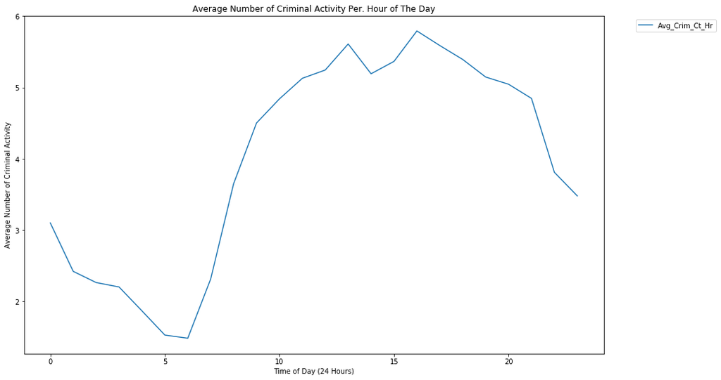

```python
# Reconfiguring the shape of the line plot.
fig_size = plt.rcParams["figure.figsize"]
fig_size[0] = 15
fig_size[1] = 9
plt.rcParams["figure.figsize"] = fig_size

# Ploting the line plot with the using the hours and avg. crime rate columns.
plt.plot(hour_df['Hour'] ,hour_df['Avg_Crim_Ct_Hr'])
plt.title('Average Number of Criminal Activity Per. Hour of The Day')
plt.ylabel('Average Number of Criminal Activity')
plt.xlabel('Time of Day (24 Hours)')
plt.legend(loc='upper right', bbox_to_anchor=(1.20, 1.0))
plt.show()
```

### 3.2 Seasonal Crime Rates

The next thing one might try to analyze in regards to time, is if there is a trend between the the crime activity and time of the year. In this respect, we can can analysis the seasons of the year to see if there is relationship between crime rates for winter season, spring season and etc.

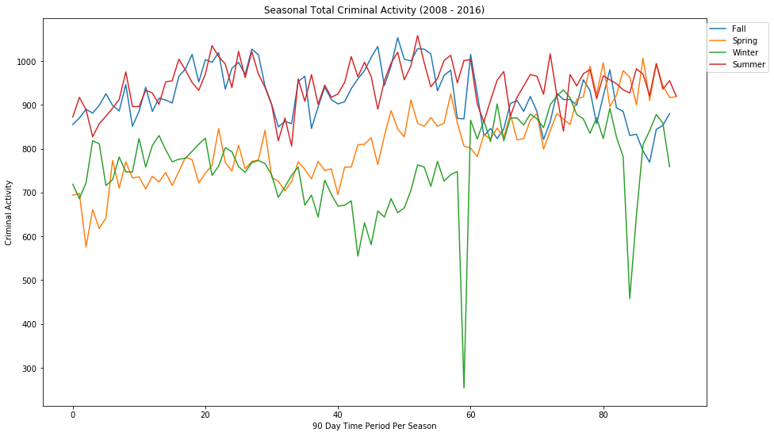

```python
# Following the Northern Meteorological Seasons
# Fall September - November
# Winter December - February
# Spring March - May
# Summer June - August
# Drag contents following the condition statements into their respected seasons data frames.
fall_crime_df = df[(df.Month >= 9) & (df.Month <= 11)]
spring_crime_df = df[(df.Month >= 3) & (df.Month <= 5)]
winter_crime_df = df[(df.Month >= 12) | ((df.Month >= 1)& (df.Month <= 2))]
summer_crime_df = df[(df.Month >= 6) & (df.Month <= 8)]

# Aggregate the total crime acts each day for all 4 seasons between the year 2008 to 2016
fall_crime_dfs = fall_crime_df.groupby(['Month','Day']).agg({\
                                                    'Criminal_Count': 'sum'}).reset_index()

spring_crime_dfs = spring_crime_df.groupby(['Month','Day']).agg({\
                                                    'Criminal_Count': 'sum'}).reset_index()

winter_crime_dfs = winter_crime_df.groupby(['Month','Day']).agg({\
                                                    'Criminal_Count': 'sum'}).reset_index()

summer_crime_dfs = summer_crime_df.groupby(['Month','Day']).agg({\
                                                    'Criminal_Count': 'sum'}).reset_index()
# Reconfiguring the shape of the line plot.
fig_size = plt.rcParams["figure.figsize"]
fig_size[0] = 15
fig_size[1] = 9
plt.rcParams["figure.figsize"] = fig_size

# Plot each individual season wich represented by each line graph shown below.
plt.plot(fall_crime_dfs.index ,fall_crime_dfs['Criminal_Count'], label = 'Fall')
plt.plot(spring_crime_dfs.index, spring_crime_dfs['Criminal_Count'], label = 'Spring')
plt.plot(winter_crime_dfs.index, winter_crime_dfs['Criminal_Count'], label = 'Winter')
plt.plot(summer_crime_dfs.index, summer_crime_dfs['Criminal_Count'], label = 'Summer')

# Labeling the graph.
plt.title('Seasonal Total Criminal Activity (2008 - 2016)')
plt.ylabel('Criminal Activity')
plt.xlabel('90 Day Time Period Per Season')
plt.legend(loc='upper right', bbox_to_anchor=(1.1, 1.0))
plt.show()
```

Observing the graph one can see that for the first two months of each season, crimes rates for spring and winter season tend be a lot lower in comparison to fall and summer. But as you look up closely, towards the end of the seasons the crime rates starts to merge, and have similar criem activity, with spring slowly creeping up into the summer season which may indicate that crimes occur because of not so extreme temperatures of the year. In addition, towards the end of fall, crime rates start to decrease, creeping into the winter season.

After looking at the trends in crimes and seasons, one can analysis the data to see if there is a change in crime activity between the years 2008 to 2016. In the possbility thay this 8 year period of crimes recorded could reveal some interesting changes in crime activity.

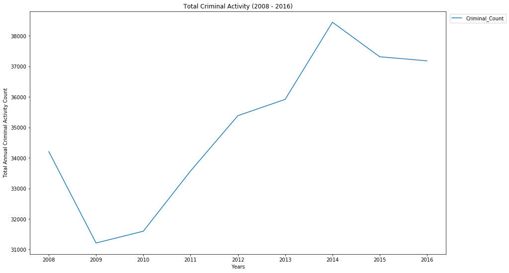

```python
# Sum up all the criminal acts for each year
period_8_yr = df.groupby('Year').agg({'Criminal_Count': 'sum'}).reset_index()
period_8_yr

# Configure size of graph
fig_size = plt.rcParams["figure.figsize"]
fig_size[0] = 15
fig_size[1] = 9
plt.rcParams["figure.figsize"] = fig_size

# Plot the line graph for 8 year period
plt.plot(period_8_yr['Year'] ,period_8_yr['Criminal_Count'])
plt.title('Total Criminal Activity (2008 - 2016)')
plt.ylabel('Total Annual Criminal Activity Count')
plt.xlabel('Years')
plt.legend(loc='upper right', bbox_to_anchor=(1.15, 1.0))
plt.show()
```

Looking at this 8 year period one can clearly see that there is huge increase in crime activity, as it starts from the year 2010, crime rates increasingly become higher and higher until it peaks in 2014. With that being said, one might wonder or try to understand might of caused this big change? Which brings us to the next part.

### 3.4 Crime Charge Popularity Chart

Previously, it was noted that there was a big change from the year 2009 to 2014. Although we can't completely narrow down an exact reason for this trend, one of features we can look at in order to try and understand this trend is to analysis the crime offense charges. By grabbing the contents of the main DC crime dataframe for the lowest point 2009-2019 and 2014-2015, we can aggregate the total amount of charges for each crime offense. Which include arson, theft homicide, burglary, assault and other offenses. After aggregating the data, we can then use [matplotlib](https://matplotlib.org/devdocs/api/_as_gen/matplotlib.pyplot.bar.html) bar functions to plot and measure all the crime offense charge to see the changes between the two groups. And hopefully getting a better understanding.

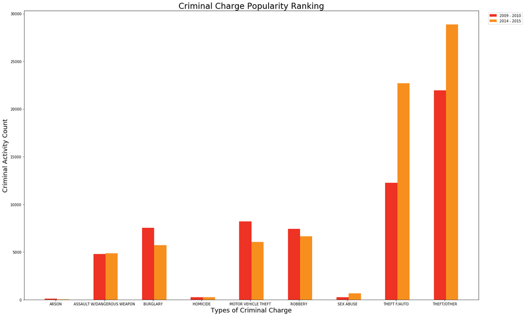

```python
# Split the main data frame into two different data frames one for the year 09-10 and 14-15.
df_09_10 = df[(df.Year == 2009) | (df.Year == 2010)]
df_14_15 = df[(df.Year == 2014) | (df.Year == 2015)]

# Sum up total offensive charges for the two groups.
charge_10 = df_09_10.groupby('Offense_Charge').agg({'Criminal_Count': 'sum'}).reset_index()
charge_15 = df_14_15.groupby('Offense_Charge').agg({'Criminal_Count': 'sum'}).reset_index()

# Configure size of graph
fig, ax = plt.subplots(figsize=(23,15))

# Labeling x and y values and plotting bar graphs for the two groups.
plt.bar([0,1,2,3,4,5,6,7,8], charge_10['Criminal_Count'], color = '#EE3224', \
            width = 0.25, label = '2009 - 2010')
plt.bar([0.25,1.25,2.25,3.25,4.25,5.25,6.25,7.25,8.25], charge_15['Criminal_Count'], \
            color = '#F78F1E', width = 0.25, label = '2014 - 2015')
ax.set_xticks([0.1,1.1,2.1,3.1,4.1,5.1,6.1,7.1,8.1])
ax.set_xticklabels(charge_10['Offense_Charge'])

# Changing the label size and rearranging the label box.
ax.set_ylabel('Criminal Activity Count', size = 18)
ax.set_xlabel('Types of Criminal Charge', size = 18)
ax.set_title('Criminal Charge Popularity Ranking', size = 23)
plt.legend(loc='upper right', bbox_to_anchor=(1.10, 1.0))
plt.show()
```

### 3.5 Crime Charge Growth Rate

So going a little more in depth into the crime offense data, we can analysis the growth rate for each crime offense charge from 2008 to 2016 to see if there any interesting trends and patterns.

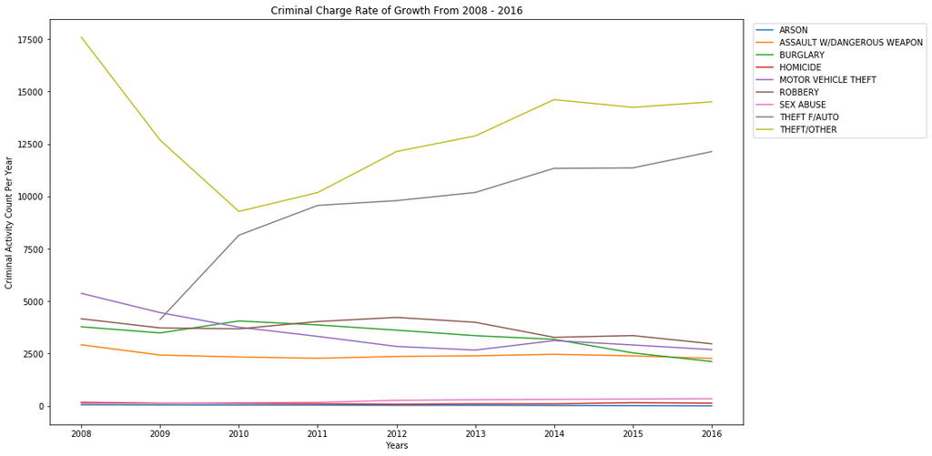

```python
# Sum all criminal acts for each criminal charge
rate_change_crime_df = df.groupby(['Year','Offense_Charge']).agg({'Criminal_Count': 'sum'}).reset_index()
charge_df = rate_change_crime_df.groupby('Offense_Charge')

# Iterate through groupby objects to label each crime charge.
for name,group in charge_df:
    plt.plot(group['Year'], group['Criminal_Count'], label = name)

# Plot line graph for each crime charge
plt.title('Criminal Charge Rate of Growth From 2008 - 2016')
plt.ylabel('Criminal Activity Count Per Year')
plt.xlabel('Years')
plt.legend(loc='upper right', bbox_to_anchor=(1.27, 1.0))
plt.show()
```

Theft/other and theft/auto clearly show a distinct difference between the rest of the other crimes with respect to the rate of change through the 8 year period. Theft/other dramtically decreases from the period 2008 to 2010 and then gradually increases all the way through 2016. In addition, theft/auto looks like the biggest growth rate, if not top two growth rates out of all the offenses.

### 3.6 Time Of Day and Crime Type

Stepping a little bit away from the crime offenses, we can look into the crime types to see if there is a relationship between time of day and degree crime type (violent vs non - violent).

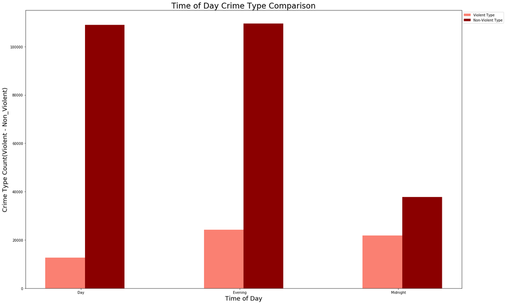

```python
# 1 = violent
# 0 = non - violent
# Split data frame into violent data frame and non violent data frame for later aggregation.
violent_split_df = df[df.Crime_Type == 1]
nviolent_split_df = df[df.Crime_Type == 0]

# Sum up total offensive charges for the two groups.
violent_df = violent_split_df.groupby('Time_of_Day').agg({'Criminal_Count': 'sum'}).reset_index()
nviolent_df = nviolent_split_df .groupby('Time_of_Day').agg({'Criminal_Count': 'sum'}).reset_index()

# Configure size of graph
fig, ax = plt.subplots(figsize=(23,15))

# Labeling x and y values and plotting bar graphs for the two groups.
plt.bar([0,1,2], violent_df['Criminal_Count'], color = 'salmon', \
            width = 0.25, label = 'Violent Type')
plt.bar([0.25,1.25,2.25], nviolent_df['Criminal_Count'], \
            color = 'darkred', width = 0.25, label = 'Non-Violent Type')
ax.set_xticks([0.1,1.1,2.1])
ax.set_xticklabels(['Day','Evening','Midnight'])

# Changing the label size and rearranging the label box.
ax.set_ylabel('Crime Type Count(Violent - Non_Violent)', size = 18)
ax.set_xlabel('Time of Day', size = 18)
ax.set_title('Time of Day Crime Type Comparison', size = 23)
plt.legend(loc='upper right', bbox_to_anchor=(1.10, 1.0))
plt.show()
```

One can that there is an overwhelming saturation in non-violent type crimes over violent type crimes. In addition, the day and evening times have significant amount more non-violent crimes than midnight crimes.

### 3.7 Offense Charges Distribution In DC

One can also look into the offense charges in the data set. By using one of python's packages, folium, one can plot markers for some of the crime data. Taking .004 of the 300,000+ data we can achieve a general pattern of which quandrant has an odd distribution of specific offense charges..

```python
# Zoom into DC coordinates
map_osm = folium.Map(location=[38.913632846803, -77.0702085907701], zoom_start=11)
# Sample DC data frame
sample_crime_df = df.sample(frac = .004, replace= False).reset_index(drop=True)
# Set up Market Clusters
marker_cluster = MarkerCluster().add_to(map_osm)

# Iterrate through dataframe plotting crime acts.
for index,row in sample_crime_df.iterrows():
    lat = row['Latitude']
    long = row['Longitude']
    if row['Offense_Charge'] == 'ARSON':
        folium.Marker([long,lat], icon=folium.Icon(color='white')).add_to(marker_cluster)
    elif row['Offense_Charge'] == 'ASSAULT W/DANGEROUS WEAPON':
        folium.Marker([long,lat], icon=folium.Icon(color='black')).add_to(marker_cluster)
    elif row['Offense_Charge'] == 'BURGLARY':
        folium.Marker([long,lat], icon=folium.Icon(color='blue')).add_to(marker_cluster)
    elif row['Offense_Charge'] == 'HOMICIDE':
        folium.Marker([long,lat], icon=folium.Icon(color='green')).add_to(marker_cluster)
    elif row['Offense_Charge'] == 'MOTOR VEHICLE THEFT':
        folium.Marker([long,lat], icon=folium.Icon(color='red')).add_to(marker_cluster)
    elif row['Offense_Charge'] == 'ROBBERY':
        folium.Marker([long,lat], icon=folium.Icon(color='purple')).add_to(marker_cluster)
    elif row['Offense_Charge'] == 'SEX ABUSE':
        folium.Marker([long,lat], icon=folium.Icon(color='grey')).add_to(marker_cluster)
    elif row['Offense_Charge'] == 'THEFT F/AUTO':
        folium.Marker([long,lat], icon=folium.Icon(color='yellow')).add_to(marker_cluster)
    else:
        folium.Marker([long,lat], icon=folium.Icon(color='pink')).add_to(marker_cluster)
map_osm
```

[interactive chart not shown]

Looking at the map, and clicking through the cluster markers, one can see that a majority of markers are densley populated around the center of all four quadrants. In addition, discovered previously there is a large representation of theft crimes relating vehicle and f/auto thats spread all over 4 quadrants.

## 4. Machine Learning & Hypothesis Testing

After completing the exploratory analysis step and now having a better understanding about our data set, the next important step is to utilize machine learning techniques. Essentially, the purpose of machine learning is to make predictions on the data set. And this depends on which kind of machine learning algorithmn one uses which can be commonly categoried into the 3 areas, supervised, unsupervised, and reinforced learning.

With this in mind, I will be using the random forest classifier which follows under the supervised learning category. Using this technique one will train the algorithm to learn data set in order to create a model to make predictions. Specifically, we will look at the "time of day" variables which consist of evening, midnight, and day and "crime type" variables, violent and non - violent crimes, to see if there is a relationship to make predictions on. In addition, for more information on machine learning algorithmns, check out: https://www.analyticsvidhya.com/blog/2017/09/common-machine-learning-algorithms/

### 4.1 Sample and Split Data

Now that we've'some of the patterns we can test data and make predictions. First step is to shuffle the row values in the data frame. After,we can split dataframe data into a training data set and testing dataset. One to teach and train the aglorithmn with, the training, and one to later test the predictions results with the, the testing data set.

```python
# Shuffle data frame rows
shuffled_df = df.sample(frac=1)
# Split data into training and testing sets.
split_data = np.random.rand(len(shuffled_df)) < 0.7
training_set = shuffled_df[split_data]
testing_set = shuffled_df[~split_data]
```

### 4.2 Set Training and Testing Data Into X and Y Values

Now we can asign time of day values to the x and y training data and crime type values to the x and y testing data. One thingto keep in mind, we only work with the training data for now, and we dont touch the testing data yet.

```python
# Split the columns into x and y training and testing data.
x_train_val = training_set[['Time_of_Day']].values
y_train_val = training_set.Crime_Type.values
x_test_val = testing_set[['Time_of_Day']].values
y_test_val = testing_set.Crime_Type.values

# Convert data type into integer
x_train_val=x_train_val.astype('int')
y_train_val=y_train_val.astype('int')
```

### 4.3 Random Forest Classifier

After we obtain the x and y training sets, we will train the algorithmn, Random Forest Classifier to fit a model from the training data to make predictions. For more in depth information about Random Forest Classifier, visit: https://medium.com/machine-learning-101/chapter-5-random-forest-classifier-56dc7425c3e1

```python
# Create a randome forest object, then use the fit function to come up with a model based
# on the x and y training data.
clf = RandomForestClassifier(n_estimators=10)
clf.fit(x_train_val, y_train_val)

# Use predict functions to make the predictions for the y values based on the testing values.
pred_outcome_y = clf.predict(x_test_val)
pred_outcome_y = pred_outcome_y.astype('int')
testing_set['Crime_Type'] = testing_set['Crime_Type'].astype('int')

# Finally, we match the accuracy of the results between the y testing values and y predicted value from the
# random forest algorithmn.
print("Accuracy for Random Forest Classifier:")
print(accuracy_score(testing_set['Crime_Type'],pred_outcome_y))
```

```
Accuracy for Random Forest Classifier:
0.813210325068
```

## Conclusion

To wrap things up, some key points to remember about this whole process is that its important to not skip any of these steps in this whoe process. Every key component of each step helps us build a more solid and accurate results. We saw that that data processing/preparation is important in cleaning up the data to be use for analysis. And then using analysis to find trends and patterns on the data set. In addition, looking back, one can see that there are many routes one can take to analysis which variables to match against. Furthermore, we could have gone deeper into the map visualization, and look which neighborhoods has the most crimes, or which crime offences are most frequent at the night. With that being said, there numerous ways to approach this step. Moving over to the next, machine learning and hypothesis testing are both important steps because its essential the whole purpose of the tutorial and for data scientist in general to carry out. We use these tools to solve problems in this world by making predictions to improve situations.

## Resources

- Matplotlib: https://matplotlib.org/api/pyplot_api.html
  - Bar graph: https://matplotlib.org/devdocs/api/_as_gen/matplotlib.pyplot.bar.html
  - Line: https://pythonspot.com/matplotlib-line-chart/
- Folium: https://github.com/python-visualization/folium
- Pandas: http://pandas.pydata.org/pandas-docs/stable/
- Numpy: https://docs.scipy.org/doc/numpy-dev/user/quickstart.html
- Random Forest Classifier: http://scikit-learn.org/stable/modules/generated/sklearn.ensemble.RandomForestClassifier.html
- Explortary Data Analysis: https://www.datacamp.com/community/tutorials/exploratory-data-analysis-python
- Data Processing: https://machinelearningmastery.com/prepare-data-machine-learning-python-scikit-learn/
- Machine learning: https://www.analyticsvidhya.com/blog/2017/09/common-machine-learning-algorithms/
- Hypothesis Testing: http://hamelg.blogspot.com/2015/11/python-for-data-analysis-part-24.html